# Session 4 HA

#Libraries und Datensatz laden

```r
library(tidyverse)
library(e1071)
library(caret)
library(pROC)
library(rpart)
library(rpart.plot)
```

```r
titanic <- read_delim("C:/Users/Data/Documents/data science/Data-Science-HAW/daten/titanic.csv", ";",
    escape_double = FALSE, trim_ws = TRUE)
```

#Aufgabe1 Bitte erstellen Sie ein Notebook mit weiteren Features (Alter, Geschlecht und Klasse sind als Beispiel in meinem Notebook auf GitHub) Neben Alter, Geschlecht und Klasse, die ja bereits einen sehr hohen Einfluss auf das Überleben auf der Titanic hatten, betrachte ich ebenfalls den Ticketpreis und den Ort, an dem das Schiff betreten wurde. Wichtige/Reiche Menschen könnten an manchen Stellen priorisiert worden sein und möglicherweise hatte der Bereich des Schiffes, in dem man untergebracht war, etwas mit den Überlebenschancen zu tun..

#Datensatz mit eigenen Features vorbereiten

```r
(titanic.df <- titanic %>%
  select(survived,pclass,sex,age,fare,embarked) %>%
   mutate(survived = as.factor(survived))%>%
  mutate(embarked = as.factor(embarked)))
```

| survived | pclass | sex | age | fare | embarked |
| --- | --- | --- | --- | --- | --- |
| 1 | 1 | female | 29 | 211,3375 | S |
| 1 | 1 | male | 0,9167 | 151,5500 | S |
| 0 | 1 | female | 2 | 151,5500 | S |
| 0 | 1 | male | 30 | 151,5500 | S |
| 0 | 1 | female | 25 | 151,5500 | S |
| 1 | 1 | male | 48 | 26,5500 | S |
| 1 | 1 | female | 63 | 77,9583 | S |
| 0 | 1 | male | 39 | 0,0000 | S |
| 1 | 1 | female | 53 | 51,4792 | S |
| 0 | 1 | male | 71 | 49,5042 | C |

[output cut: 990 more lines]

```r
titanic.df <- titanic.df %>%
  mutate(fare = as.numeric(str_replace(fare,",","."))) %>%
  mutate(age = as.numeric(str_replace(age,",",".")))
```

```r
titanic.df <- na.omit(titanic.df)
```

```r
titanic.df <- titanic.df %>%
  mutate(sex = ifelse(sex == "female", 1, 0))
```

#Aufgabe2 Was sind die Unterschiede in der Performance der Algorithmen? Um die Performance der Algorithmen betrachten zu können, lasse ich zunächst jeden Algorithmus mit dem neuen Datensatz aus Aufgabe 1 Durchlaufen.

#Durchführung SVM-Klassifikation

```r
set.seed(393)
inTrain <- createDataPartition(
  y = titanic.df$survived,
  p = .8,
  list = FALSE)
training <- titanic.df[ inTrain,]
testing  <- titanic.df[-inTrain,]
```

```r
model.svm <- svm(formula = survived ~ ., data = training, probability=TRUE)
summary(model.svm)
```

```
Call:
svm(formula = survived ~ ., data = training, probability = TRUE)


Parameters:
   SVM-Type:  C-classification
 SVM-Kernel:  radial
       cost:  1

Number of Support Vectors:  398

 ( 194 204 )


Number of Classes:  2

Levels:
 0 1
```

```r
pred <- predict(model.svm, testing[,-1], probability = TRUE)
```

```r
(test.results <- cbind(pred, testing))
```

|  | pred | survived | pclass | sex | age | fare | embarked |
| --- | --- | --- | --- | --- | --- | --- | --- |
| 1 | 1 | 1 | 1 | 0 | 0.9167 | 151.5500 | S |
| 2 | 1 | 1 | 1 | 1 | 18.0000 | 227.5250 | C |
| 3 | 1 | 1 | 1 | 1 | 24.0000 | 69.3000 | C |
| 4 | 0 | 0 | 1 | 0 | 24.0000 | 247.5208 | C |
| 5 | 0 | 0 | 1 | 0 | 25.0000 | 26.0000 | C |
| 6 | 0 | 0 | 1 | 0 | 42.0000 | 26.5500 | S |
| 7 | 1 | 1 | 1 | 1 | 59.0000 | 51.4792 | S |
| 8 | 1 | 1 | 1 | 1 | 60.0000 | 76.2917 | C |
| 9 | 0 | 0 | 1 | 0 | 45.0000 | 26.5500 | S |
| 10 | 1 | 1 | 1 | 1 | 58.0000 | 512.3292 | C |

[output cut: 198 more lines]

```r
head(attr(pred, "probabilities"))
```

```
          1          0
1 0.7319951 0.26800488
2 0.8926804 0.10731960
3 0.9651983 0.03480171
4 0.4421904 0.55780957
5 0.4866961 0.51330386
6 0.2232904 0.77670956
```

```r
confusionMatrix(pred,testing$survived)
```

```
Confusion Matrix and Statistics

          Reference
Prediction   0   1
         0 120  34
         1   3  51

               Accuracy : 0.8221
                 95% CI : (0.7632, 0.8716)
    No Information Rate : 0.5913
    P-Value [Acc > NIR] : 8.204e-13

                  Kappa : 0.61

 Mcnemar's Test P-Value : 8.140e-07

            Sensitivity : 0.9756
            Specificity : 0.6000
         Pos Pred Value : 0.7792
         Neg Pred Value : 0.9444
             Prevalence : 0.5913
         Detection Rate : 0.5769
   Detection Prevalence : 0.7404
      Balanced Accuracy : 0.7878

       'Positive' Class : 0
```

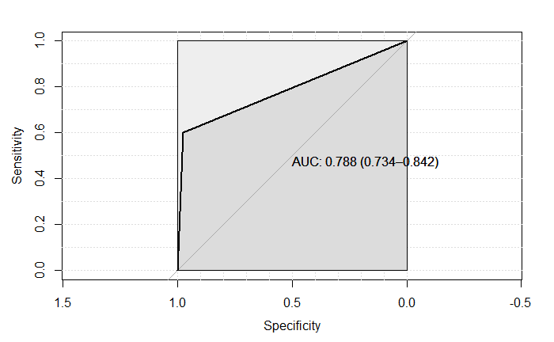

```r
pROC_obj <- roc(as.numeric(test.results$survived), as.numeric(test.results$pred),
            smoothed = TRUE,
            ci=TRUE, ci.alpha=0.9, stratified=FALSE,
            plot=TRUE, auc.polygon=TRUE, max.auc.polygon=TRUE, grid=TRUE,
            print.auc=TRUE, show.thres=TRUE)
```

#Naive Bayes

#Daten vorbereiten Zunächst müssen alle Datensätze zu factors umgewandelt werden. Da die Ticketkosten sich kaum doppeln und es zu viele level geben würde, werden die Kosten in die Kategorien “cheap” (0-50), “normal” (51-100), “expensive” (101-200) und “luxury” (201+) unterteilt. Diese Kategorien werden anschließend in factors umgewandelt. Die Wahl der Kategoriegrenzen wurde willkürlich gewählt, da eine sinnvolle Einschätzung der Ticketpreise ein gewisses Maß an Wissen über die damalige finanzielle Situation der Menschen erfordern würde.

```r
training$fare_category[training$fare >= 0] = "cheap"
```

```
Unknown or uninitialised column: `fare_category`.
```

```r
training$fare_category[training$fare >= 51 ] = "normal"
training$fare_category[training$fare >= 101] = "expensive"
training$fare_category[training$fare >= 201 ] = "luxury"
training$fare_category = factor(training$fare_category,
                    levels=c("cheap", "normal", "expensive","luxury" ))
training$fare <- NULL
```

```r
testing$fare_category[testing$fare >= 0] = "cheap"
```

```
Unknown or uninitialised column: `fare_category`.
```

```r
testing$fare_category[testing$fare >= 51 ] = "normal"
testing$fare_category[testing$fare >= 101] = "expensive"
testing$fare_category[testing$fare >= 201 ] = "luxury"
testing$fare_category = factor(testing$fare_category,
                    levels=c("cheap", "normal", "expensive","luxury" ))
testing$fare <- NULL
```

```r
my_training <- training %>%
  mutate(sex = as.factor(sex))%>%
  mutate(pclass = as.factor(pclass)) %>%
  mutate(age = as.factor(ifelse(age < 14, "child", "adult")))
```

#Durchführung des Algorithmus

```r
my_training <- training %>%
  mutate(sex = as.factor(sex))%>%
  mutate(pclass = as.factor(pclass)) %>%
  mutate(age = as.factor(ifelse(age < 14, "child", "adult")))
model <- naiveBayes(survived ~ ., data = my_training)
model
```

```
Naive Bayes Classifier for Discrete Predictors

Call:
naiveBayes.default(x = X, y = Y, laplace = laplace)

A-priori probabilities:
Y
        0         1
0.5928144 0.4071856

Conditional probabilities:
   pclass
Y           1         2         3
  0 0.1474747 0.2363636 0.6161616
  1 0.4264706 0.2852941 0.2882353

   sex
Y           0         1
  0 0.8323232 0.1676768
  1 0.3294118 0.6705882

   age
Y        adult      child
  0 0.92323232 0.07676768
  1 0.87352941 0.12647059

   embarked
Y            C          Q          S
  0 0.13333333 0.06666667 0.80000000
  1 0.31176471 0.02941176 0.65882353

   fare_category
Y        cheap     normal  expensive     luxury
  0 0.88888889 0.07676768 0.02020202 0.01414141
  1 0.65882353 0.20294118 0.07058824 0.06764706
```

```r
my_testing <- testing %>%
  mutate(sex = as.factor(sex)) %>%
  mutate(pclass = as.factor(pclass))%>%
  mutate(age = as.factor(ifelse(age < 14, "child", "adult")))
pred <- predict(model, my_testing)
table(pred, my_testing$survived)
```

```
pred   0   1
   0 102  28
   1  21  57
```

```r
(test.results <- cbind(pred, my_testing))
```

| pred | survived | pclass | sex | age | embarked | fare_category |
| --- | --- | --- | --- | --- | --- | --- |
| 1 | 1 | 1 | 0 | child | S | expensive |
| 1 | 1 | 1 | 1 | adult | C | luxury |
| 1 | 1 | 1 | 1 | adult | C | normal |
| 1 | 0 | 1 | 0 | adult | C | luxury |
| 1 | 0 | 1 | 0 | adult | C | cheap |
| 0 | 0 | 1 | 0 | adult | S | cheap |
| 1 | 1 | 1 | 1 | adult | S | normal |
| 1 | 1 | 1 | 1 | adult | C | normal |
| 0 | 0 | 1 | 0 | adult | S | cheap |
| 1 | 1 | 1 | 1 | adult | C | luxury |

[output cut: 198 more lines]

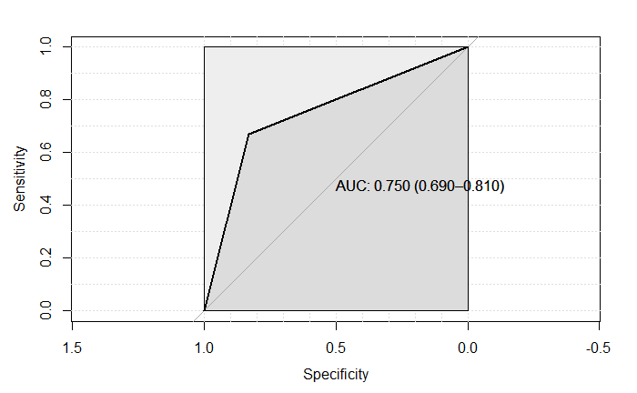

```r
test.results <- test.results %>%
  mutate(pred = as.numeric(pred))
pROC_obj <- roc(as.numeric(as.factor(test.results$survived)), test.results$pred,
            smoothed = TRUE,
            ci=TRUE, ci.alpha=0.9, stratified=FALSE,
            plot=TRUE, auc.polygon=TRUE, max.auc.polygon=TRUE, grid=TRUE,
            print.auc=TRUE, show.thres=TRUE)
```

# Decision Tree

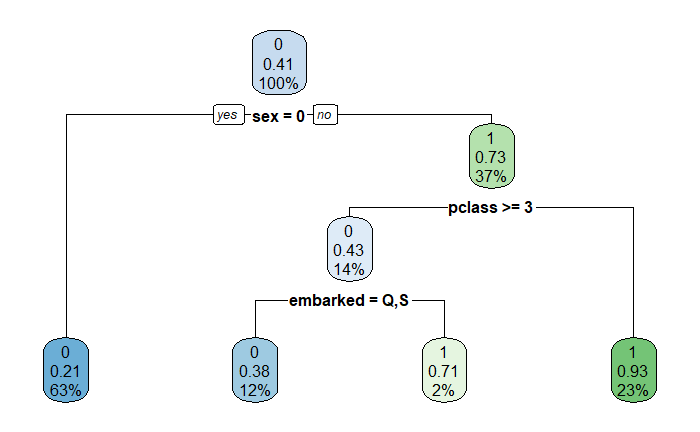

```r
tree<- rpart(survived~., data = training, method = 'class')
rpart.plot(tree)
```

```r
dt_results <- predict(tree, testing[,-1], type = 'prob')
head(model.results.dt <- cbind(testing,dt_results),500)
```

|  | survived | pclass | sex | age | embarked | fare_category | 0 | 1 |
| --- | --- | --- | --- | --- | --- | --- | --- | --- |
| 1 | 1 | 1 | 0 | 0.9167 | S | expensive | 0.78625954 | 0.2137405 |
| 2 | 1 | 1 | 1 | 18.0000 | C | luxury | 0.07368421 | 0.9263158 |
| 3 | 1 | 1 | 1 | 24.0000 | C | normal | 0.07368421 | 0.9263158 |
| 4 | 0 | 1 | 0 | 24.0000 | C | luxury | 0.78625954 | 0.2137405 |
| 5 | 0 | 1 | 0 | 25.0000 | C | cheap | 0.78625954 | 0.2137405 |
| 6 | 0 | 1 | 0 | 42.0000 | S | cheap | 0.78625954 | 0.2137405 |
| 7 | 1 | 1 | 1 | 59.0000 | S | normal | 0.07368421 | 0.9263158 |
| 8 | 1 | 1 | 1 | 60.0000 | C | normal | 0.07368421 | 0.9263158 |
| 9 | 0 | 1 | 0 | 45.0000 | S | cheap | 0.78625954 | 0.2137405 |
| 10 | 1 | 1 | 1 | 58.0000 | C | luxury | 0.07368421 | 0.9263158 |

[output cut: 198 more lines]

```r
test.results2 <- test.results %>%
  mutate(pred = ifelse(pred>=0.5,1,0))
table(test.results2$pred, testing$survived)
```

```
      0   1
  1 123  85
```

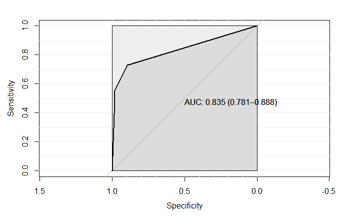

```r
pROC_obj <- roc(model.results.dt$survived,model.results.dt$`1`,
            smoothed = TRUE,
            # arguments for ci
            ci=TRUE, ci.alpha=0.9, stratified=FALSE,
            # arguments for plot
            plot=TRUE, auc.polygon=TRUE, max.auc.polygon=TRUE, grid=TRUE,
            print.auc=TRUE, show.thres=TRUE)
```

#Performance der Algorithmen

#Support Vector Machines AUC: 0,788

#Naive Bayes AUC: 0,750

#Decision Tree AUC: 0,835

[output not shown]

#Aufgabe3 Finden Sie Erklärungen dafür. Der Hauptgrund wird vermutlich in der Qualität meines Datensatzes liegen. Die Variablen embarked und fare scheinen keinen großen Einfluss auf die Überlebenschancen gehabt zu haben, was die Performance der Algorithmen behindert. Gerade Naive Bayes, bei dem die Variablen unabhängig voneinander betrachtet werden, scheint bei der Gesamtberechnung der Überlebenschancen sehr anfällig für unsinnige Variablen zu sein. Dazu kommt, dass ich die fare-Werte für den Naive Bayes Algorithmuseh willkürlich in Kategorien zusammengefasst habe, was die Performance von Naive Bayes vermutlich auch eingeschränkt hat.